# Introduction to Solving Biological Problems Using R - Day 2

Mark Dunning, Suraj Menon and Aiora Zabala. Original material by Robert Stojnić, Laurent Gatto, Rob Foy, John Davey, Dávid Molnár and Ian Roberts

Last modified: 26 May 2017

# Day 2 Schedule

1. Further customisation of plots
2. Statistics
3. Data Manipulation Techniques
4. Programming in R
5. Further report writing

# 1. Further customisation of plots

## Recap

- We have seen how to use `plot()`, `boxplot()` , `hist()` etc to make simple plots
- These come with arguments that can be used to change the appearance of the plot
  - `col`, `pch`
  - `main`, `xlab`, `ylab`
  - etc….
- We will now look at ways to modify the plot appearance after it has been created
- Also, how to export the graphs

## The painter’s model

- R employs a painter’s model to construct it’s plots
- Elements of the graph are added to the canvas one layer at a time, and the picture built up in levels.
- Lower levels are obscured by higher levels,
  - allowing for blending, masking and overlaying of objects.
- You can’t undo the changes you make to the plot
  - you have to re-run the code from scratch

[figure not shown]

http://www.inquisitr.com/309687/jesus-painting-restoration-goes-wrong-well-intentioned-old-lady-destroys-100-year-old-fresco/

- We will re-use the patients data from yesterday:

```r
patients <- read.delim("patient-info.txt")
```

- Recall our patients dataset from yesterday
  - we might want to display other characteristics on the plot, e.g. gender of individual:

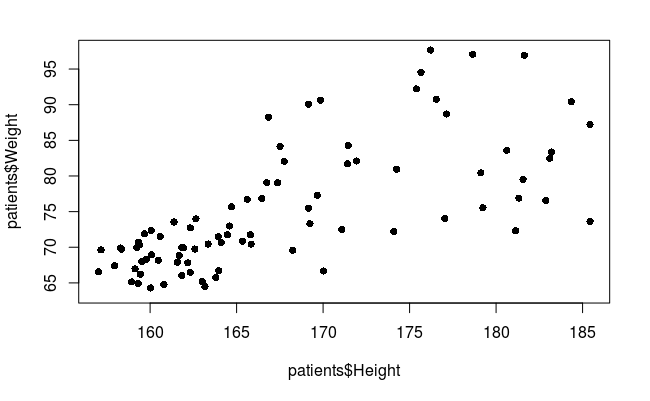

```r
plot(patients$Height, patients$Weight, pch=16)
```

## The points function

- `points()` can be used to set of points to an *existing* plot
- It requires a vector of x and y coordinates
  - These do not have to be the same length as the number of points in the initial plot:
    - Hence we can use `points()` to highlight observations
    - …or add a set of new observations

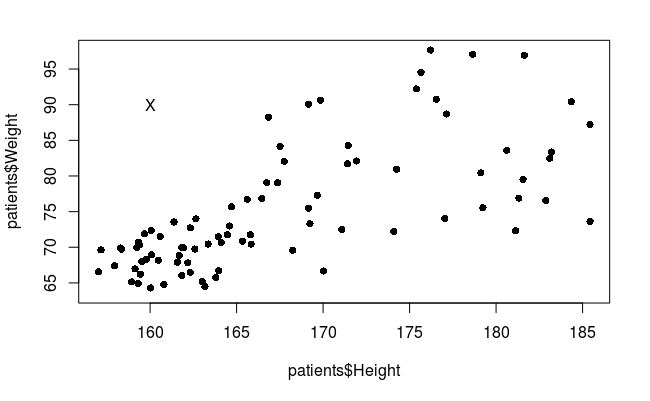

```r
plot(patients$Height, patients$Weight, pch=16)
points(160,90, pch="X")
```

- Note that axis limits of the existing plot are not altered
- Often it is useful to create a blank ‘canvas’ with the correct labels and limits

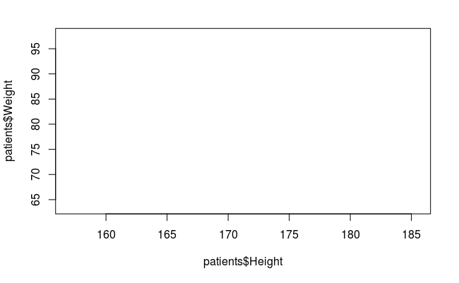

```r
plot(patients$Height, patients$Weight, type="n")
```

## Adding points to differentiate gender

- Selecting males using the **`==`** comparison we saw yesterday
  - Gives a `TRUE` or `FALSE` value
  - Can be used to index the data frame
  - Which means we can get the relevant Age and Weight values

```r
males <- patients$Sex == "Male"
males
```

```
  [1]  TRUE  TRUE  TRUE  TRUE FALSE FALSE FALSE FALSE  TRUE  TRUE FALSE FALSE  TRUE FALSE FALSE  TRUE  TRUE  TRUE  TRUE  TRUE  TRUE FALSE  TRUE FALSE
 [25] FALSE  TRUE  TRUE  TRUE  TRUE  TRUE FALSE  TRUE  TRUE FALSE  TRUE FALSE  TRUE FALSE  TRUE FALSE  TRUE FALSE FALSE FALSE FALSE FALSE FALSE FALSE
 [49]  TRUE FALSE FALSE FALSE FALSE FALSE  TRUE FALSE FALSE FALSE  TRUE  TRUE FALSE  TRUE FALSE  TRUE  TRUE FALSE  TRUE FALSE  TRUE FALSE FALSE  TRUE
 [73]  TRUE FALSE  TRUE FALSE  TRUE  TRUE FALSE FALSE FALSE FALSE  TRUE FALSE FALSE FALSE FALSE  TRUE FALSE  TRUE  TRUE  TRUE FALSE  TRUE FALSE FALSE
 [97] FALSE FALSE FALSE FALSE
```

```r
males
patients[males,]
patients$Age[males]
patients$Weight[males]
```

- The points we add have to be within the `x` and `y` limits of the original plot axes, otherwise they won’t be displayed
  - R won’t give a warning or error if you attempt to plot points outside the axis limits

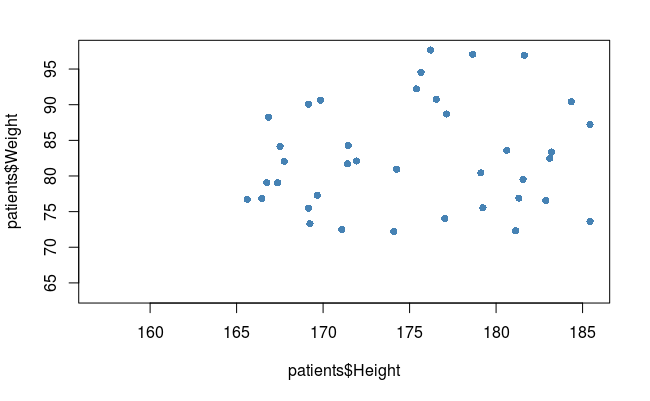

```r
plot(patients$Height, patients$Weight, type="n")
points(patients$Height[males], patients$Weight[males],
       pch=16, col="steelblue")
```

We can do the same for Females

```r
females <- patients$Sex == "Female"
females
```

```
  [1] FALSE FALSE FALSE FALSE  TRUE  TRUE  TRUE  TRUE FALSE FALSE  TRUE  TRUE FALSE  TRUE  TRUE FALSE FALSE FALSE FALSE FALSE FALSE  TRUE FALSE  TRUE
 [25]  TRUE FALSE FALSE FALSE FALSE FALSE  TRUE FALSE FALSE  TRUE FALSE  TRUE FALSE  TRUE FALSE  TRUE FALSE  TRUE  TRUE  TRUE  TRUE  TRUE  TRUE  TRUE
 [49] FALSE  TRUE  TRUE  TRUE  TRUE  TRUE FALSE  TRUE  TRUE  TRUE FALSE FALSE  TRUE FALSE  TRUE FALSE FALSE  TRUE FALSE  TRUE FALSE  TRUE  TRUE FALSE
 [73] FALSE  TRUE FALSE  TRUE FALSE FALSE  TRUE  TRUE  TRUE  TRUE FALSE  TRUE  TRUE  TRUE  TRUE FALSE  TRUE FALSE FALSE FALSE  TRUE FALSE  TRUE  TRUE
 [97]  TRUE  TRUE  TRUE  TRUE
```

```r
patients[females,]
```

|  | ID | Race | Sex | Smokes | Height | Weight | State | Pet | Grade | Age |
| --- | --- | --- | --- | --- | --- | --- | --- | --- | --- | --- |
| 5 | AC/AH/029 | White | Female | Non-Smoker | 164.47 | 71.78 | Iowa | NA | 2 | 70 |
| 6 | AC/AH/033 | NA | Female | Smoker | 158.27 | 69.90 | Maryland | Dog | 2 | 66 |
| 7 | AC/AH/037 | White | Female | Non-Smoker | 161.69 | 68.85 | Pennsylvania | None | 1 | 24 |
| 8 | AC/AH/044 | White | Female | Non-Smoker | 165.84 | 70.44 | North Carolina | None | 1 | 68 |
| 11 | AC/AH/049 | White | Female | Non-Smoker | 160.06 | 72.37 | California | Horse | 2 | 82 |
| 12 | AC/AH/050 | White | Female | Non-Smoker | 166.48 | NA | Michigan | None | 1 | 31 |
| 14 | AC/AH/053 | White | Female | Smoker | 164.70 | 75.69 | Virginia | Dog | 1 | 41 |
| 15 | AC/AH/057 | White | Female | Smoker | 163.79 | 65.76 | Illinois | Cat | 3 | 43 |
| 22 | AC/AH/100 | White | Female | Non-Smoker | 161.92 | 69.92 | Georgia | Dog | 1 | 32 |
| 24 | AC/AH/112 | Black | Female | Non-Smoker | NA | 63.54 | California | NA | NA | 29 |

[output cut: 45 more lines]

- Again, we have to be careful that all the points are within the `x` and `y` limits
  - this is why creating the blank plot containing the limits of the data is useful

```r
plot(patients$Height, patients$Weight, type="n")
points(patients$Height[males], patients$Weight[males],
       pch=16, col="steelblue")
```

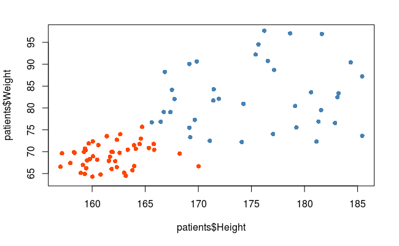

```r
points(patients$Height[females], patients$Weight[females],
       pch=16, col="orangered1")
```

- Each set of points can have a different colour and shape
- Axis labels and title and limits are defined by the plot
- Once you’ve added points to a plot, they cannot be removed

```r
plot(patients$Height, patients$Weight, type="n")
points(patients$Height[males], patients$Weight[males],
       pch=16, col="steelblue")
```

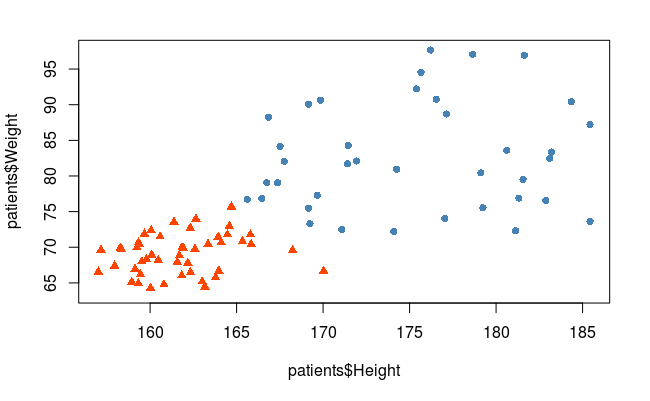

```r
points(patients$Height[females], patients$Weight[females],
       pch=17, col="orangered1",
        xlab="Age of Patient",
       ylab="Weight",
       main="Relationship between Age and Weights")
```

## Adding a legend

- Should also add a legend to help interpret the plot
  - use the `legend` function
  - can give x and y coordinates where legend will appear
  - also recognises shortcuts such as *topleft* and *bottomright*…

```r
plot(patients$Height, patients$Weight, type="n")
points(patients$Height[males], patients$Weight[males],
       pch=16, col="steelblue")
```

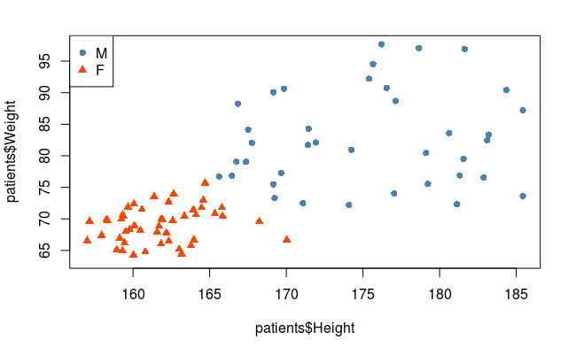

```r
points(patients$Height[females], patients$Weight[females],
       pch=17, col="orangered1")
legend("topleft", legend=c("M","F"),
       col=c("steelblue","orangered1"), pch=c(16,17))
```

## Adding text

- Text can also be added to a plot in a similar manner
  - the `labels` argument specifies the text we want to add

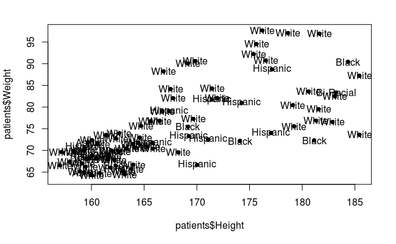

```r
plot(patients$Height, patients$Weight, pch=16)
  text(patients$Height, patients$Weight, labels=patients$Race)
```

- In the above we used to same co-ordinates from the original plot to place the text
- Can also add text at arbitrary positions
  - again, we need to take care as the axis limits are defined in the original plot

```r
plot(patients$Height, patients$Weight, pch=16)
text(160,95, labels = "X",col="red")
```

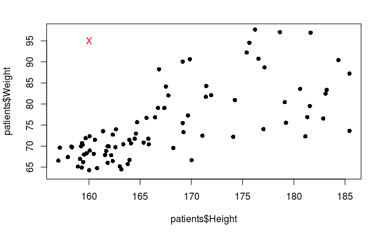

```r
text(90,100, labels = "Y",col="blue")
```

- To aid our interpretation, it is often helpful to add guidelines
  - `grid()` is one easy way of doing this:

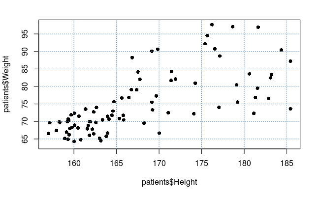

```r
plot(patients$Height, patients$Weight, pch=16)
grid(col="steelblue")
```

- Can also add lines that intersect the axes:
  - `v =` for vertical lines
  - `h =` for horizontal
  - can specify multiple lines in a vector

```r
plot(patients$Height, patients$Weight, pch=16)
abline(v=160, col="red")
```

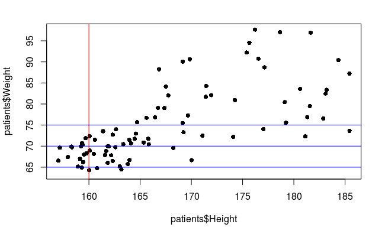

```r
abline(h=c(65,70,75), col="blue")
```

## Plot layouts

- The `par` function can be used specify the appearance of a plot
- The settings persist until the plot is closed with **`dev.off()`**
- `?par` and scroll to *graphical parameters*
- One example is `mfrow`:
  - “multiple figures per row”
  - needs to be a vector of rows and columns:
    - e.g. a plot with one row and two columns `par(mfrow=c(1,2))`
    - don’t need the same kind of plot in each cell

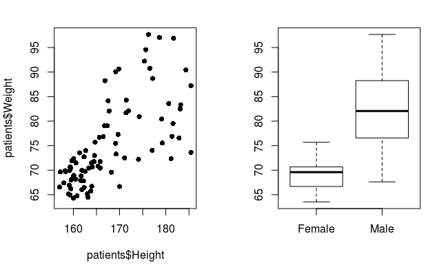

```r
par(mfrow=c(1,2))
plot(patients$Height, patients$Weight, pch=16)
boxplot(patients$Weight ~ patients$Sex)
```

- See also `mar` for setting the margins:
  - `par(mar=c(...))`

## Exporting graphs from RStudio

- You can use the `pdf()` function to export one or more plots to a pdf file:
  - You will see that the plot does not appear in RStudio
- You need to use the `dev.off()` to stop printing graphs to the pdf and ‘close’ the file
  - It allows you to create a pdf document with multiple pages

```r
pdf("ExampleGraph.pdf")
boxplot(patients$Weight ~ patients$Sex)
dev.off()
```

- pdf is a good choice for publication as they can be imported into Photoshop, Inkscape, etc.
  - Sometimes it is easier to edit in these tools than R!
  - If it is taking too long to customise a plot in R, consider if you should be using one of these tools instead
- To save any graph you have created to a pdf, repeat the code you used to create the plot with `pdf()` before and `dev.off()` afterwards
  - you can have as many lines of code in-between as you like
  - each new plot will be written to a different page

```r
pdf("mygraph.pdf")
plot(patients$Height, patients$Weight, pch=16)
abline(v=40, col="red")
abline(h=c(65,70,75), col="blue")
boxplot(patients$Weight ~ patients$Sex)
```

```r
x <- 1:10
y <- x^2 + 4*x
plot(x,y)
dev.off()
```

- If no plots are appearing in RStudio, it could be you are still writing to a pdf file
  - run `dev.off()` multiple times until you see a message `cannot shut down device (the null device)`
- We can specify the dimensions of the plot, and other properties of the file (`?pdf`)

```r
pdf("ExampleGraph.pdf", width=10, height=5)
boxplot(patients$Weight ~ patients$Sex)
dev.off()
```

- Other formats can be created:
  - e.g. *png*, or others `?jpeg`
  - more appropriate for email, presentations, web page

```r
png("ExampleGraph.png")
boxplot(patients$Weight ~ patients$Sex)
dev.off()
```

## Exercise: Exercise 5a

- Return to the weather data from yesterday:

```r
weather <- read.csv("ozone.csv")
```

- Using the `par` function, create a layout with three columns
- Plot Ozone versus Solar Radiation, Wind Speed and Temperature on separate graphs
  - use different colours and plotting characters on each plot
- Save the plot to a pdf
- HINT: Create the graph first in RStudio. When you’re happy with it, re-run the code preceeded by the `pdf` function to save to a file
  - don’t forget to use `dev.off()` to close the file

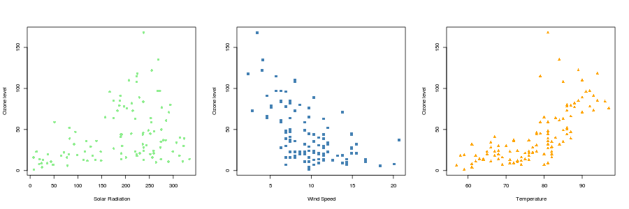

```r
### Your Answer Here ###
```

## Exercise: Exercise 5b

- Temperature and Ozone level seem to be correlated
- However, there are some observations that do not seem to fit the trend
  - those with Ozone level > 100
- Modify the plot so that these outlier observations are in a different colour
- Add a legend to help interpret the plot

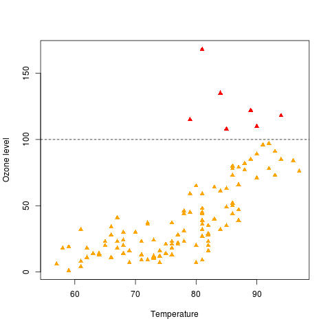

HINT: You can break down the problem into the following steps

- Create a blank plot
- Identify observations with ozone > 100
  - plot the corresponding Temperature and Ozone values for these in red
- Identify observations with ozone < 100
  - plot the corresponding Temperature and Ozone values for these in orange
- Can you modify your code so that the cut-off is not hard-coded (fixed) to 100
  - e.g. Ozone > 80, Ozone, 90 etc…
  - can you re-generate the plots the minimal changes to the code

```r
### Your Answer Here ###
```

## Other plotting features

We can choose not to show the x- and y-axis in the initial plot

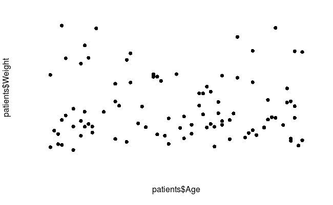

```r
plot(patients$Age, patients$Weight, pch=16,axes=FALSE)
```

They can be added afterwards with the `axis` function - first argument is whether the axis appears on the bottom (1), left (2), top (3) or right (4) - can also define where the tick marks are located, and the labels to display - the `box` function can be used to enclose the plot in a box

```r
plot(patients$Age, patients$Weight, pch=16,axes=FALSE)
axis(1)
```

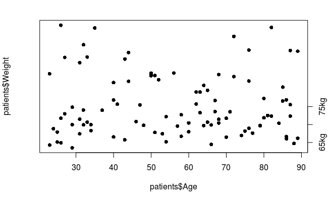

```r
axis(4, at = c(60,65,70,75),labels = c("60kg","65kg","70kg","75kg"))
box()
```

## Ordering the boxes in a set of boxplots

N.B. The order in which the boxes are displayed on a boxplot isn’t something that can be controlled by graphical paramaters

- the order is derived from the order of the categories
  - in this case `Female` comes first alphabetically

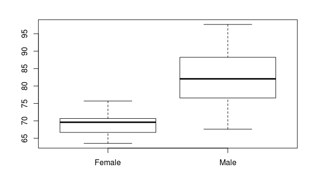

```r
boxplot(patients$Weight~patients$Sex)
```

- a different order can be achieved by defining a new factor where the `levels` are in the order you want

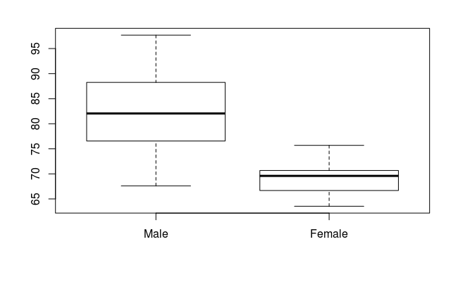

```r
patients$Sex <- factor(patients$Sex,levels = c("Male","Female"))
boxplot(patients$Weight~patients$Sex)
```

## Need inspiration?

The [R Graph Gallery](http://www.r-graph-gallery.com/) has lots of examples (and code) showing what can be achieved with R graphics